# Building a Sonar with a Microphone and Deep Neural Networks

In this notebook, we'll try and see if we can determine the distance to a wall by emitting a sound with a particular frequency and listening to it by a microphone array.

Theoretically, the sample rate of the microphone is high enough to capture both, the original sound and its echo. We will record the sound emitted and its capture in a noisy room and then try and train a DNN to correlate the echo with the distance to the wall.

[figure not shown]

### Data Collection

The microphone array used is a PS3 eye toy. The sound is emitted with a mono speaker placed behind the array. The sound and echo is recorded in 4 channel audio. The distance in a straight line is recorded between the microphone array and the wall in inches.

### Methodology

```python
import math
import tensorflow as tf
from tensorflow.keras.layers import Input, Dense, Flatten, LSTM, Reshape, Dropout
from tensorflow.keras.layers import Conv2D, MaxPooling2D, BatchNormalization
from tensorflow.keras.models import Model, Sequential, model_from_json
from tensorflow.keras import optimizers
import numpy as np
import scipy.io.wavfile
import os
from os.path import normpath, basename
import matplotlib
import matplotlib.pyplot as plt
from sklearn.preprocessing import MinMaxScaler
import matplotlib.image as mpimg
from IPython.display import display, Markdown, Latex
```

Setup some of the recording properties

```python
audio_sample_rate = 48000
channels = 1
num_seconds_in_audio = 2 * 60; # two minute data files
```

```python
def load_data(num_seconds, channels, sample_rate):
    sample_len = num_seconds * sample_rate

    data_x = np.empty((0, sample_len, channels))
    data_y = np.empty((0))
    for subdir, dirs, files in os.walk('data'):
        for file in files:
            filepath = subdir + os.sep + file
            distance = int(basename(normpath(subdir)))

            samples, data = scipy.io.wavfile.read(filepath)
            data = data[:sample_len]

            if (data.shape[0] < sample_len):
                continue

            if (len(data.shape) == 1):
                data = data.reshape(-1, 1)

            for channel in range(0, data.shape[1]):
                data_x = np.concatenate((data_x, data[:,channel].reshape(-1, sample_len, channels)), axis=0)
                data_y = np.append(data_y, distance)

    return (data_x, data_y)
```

```python
import pandas as pd
import seaborn as sns
sns.set(color_codes=True)

import matplotlib.pyplot as plt
from scipy import stats

data_x, data_y = load_data(num_seconds_in_audio, channels, audio_sample_rate)
```

```
(28, 5760000, 1)
(28,)
```

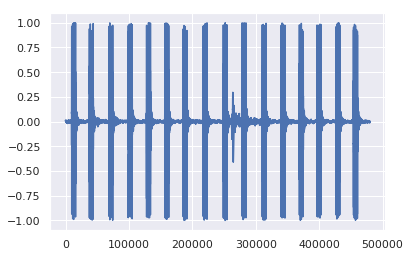

Looks like a series of chirps followed by some gaps. Lets take a closer look

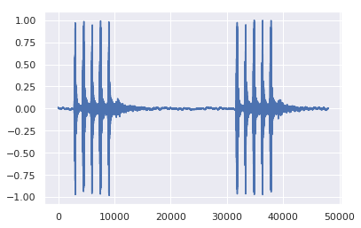

And each chirp looks like this

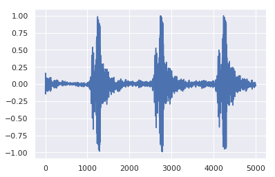

```python
print(data_x.shape)
print(data_y.shape)

plt.plot(data_x[0][:audio_sample_rate * 10])
plt.show()

display(Markdown('#### Looks like a series of chirps followed by some gaps. Lets take a closer look'))

plt.plot(data_x[0][audio_sample_rate * 2:audio_sample_rate * 3])
plt.show()

display(Markdown('#### And each chirp looks like this'))

plt.plot(data_x[0][10000:15000])
plt.show()
```

Looks like there are odd spikes in the audio files and also the scale is off between different audio files probably due to different DB

```
For sample 0, std: 0, mean: 0, max: 1
For sample 1, std: 0, mean: 0, max: 1
For sample 2, std: 0, mean: 0, max: 1
For sample 3, std: 0, mean: 0, max: 1
For sample 4, std: 0, mean: 0, max: 1
For sample 5, std: 0, mean: 0, max: 1
For sample 6, std: 0, mean: 0, max: 1
For sample 7, std: 0, mean: 0, max: 1
For sample 8, std: 0, mean: 0, max: 1
For sample 9, std: 0, mean: 0, max: 1
For sample 10, std: 0, mean: 0, max: 1
For sample 11, std: 0, mean: 0, max: 1
For sample 12, std: 0, mean: 0, max: 1
For sample 13, std: 0, mean: 0, max: 1
For sample 14, std: 0, mean: 0, max: 1
For sample 15, std: 0, mean: 0, max: 1
For sample 16, std: 0, mean: 0, max: 1
For sample 17, std: 0, mean: 0, max: 1
For sample 18, std: 0, mean: 0, max: 1
For sample 19, std: 0, mean: 0, max: 1
For sample 20, std: 0, mean: 0, max: 1
For sample 21, std: 0, mean: 0, max: 1
For sample 22, std: 0, mean: 0, max: 1
For sample 23, std: 0, mean: 0, max: 1
For sample 24, std: 0, mean: 0, max: 1
For sample 25, std: 0, mean: 0, max: 1
For sample 26, std: 0, mean: 0, max: 1
For sample 27, std: 0, mean: 0, max: 1
mean: 0.00016700064884962883
```

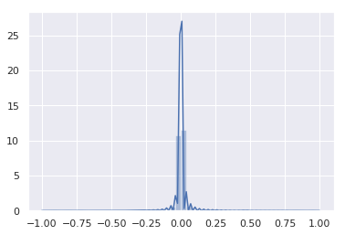

```python
display(Markdown('#### Looks like there are odd spikes in the audio files and also the scale is off between different audio files probably due to different DB'))

def scale(X, x_min, x_max):
    nom = (X-X.min(axis=0))*(x_max-x_min)
    denom = X.max(axis=0) - X.min(axis=0)
    denom[denom==0] = 1
    return x_min + nom/denom

for i, _ in enumerate(data_x):
    print("For sample %d, std: %d, mean: %d, max: %d" % (i, np.std(data_x[i]), np.mean(data_x[i]), np.max(data_x[i])))
    data_x[i][abs(data_x[i] - np.mean(data_x[i])) >= 10 * np.std(data_x[i])] = 0
    data_x[i] = scale(data_x[i], -1, 1)

print("mean: " + str(np.mean(data_x[0])))
sns.distplot(data_x[0].flatten())
```

### Data cleanup methodology

So looks like the audio files contain a sequence of chirps, followed by a gap and more sequence of chirps. Within each sequence, we can see that in the beginning there is a high decibal chirp, followed by ambient noise together with any echo's that might be present.

So, to clean up the input, lets ignore all the ambient noise in between the chirp sequences, and within each sequence lets separate out individual chirps.

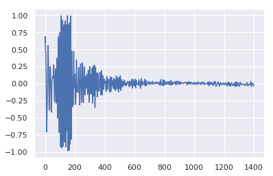

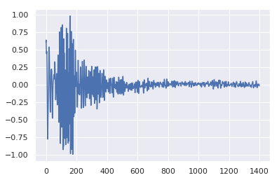

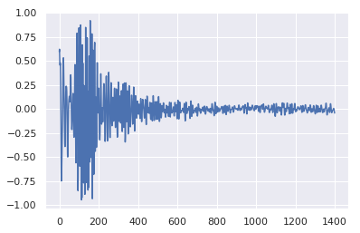

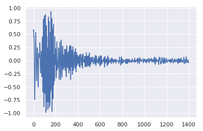

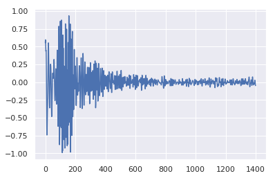

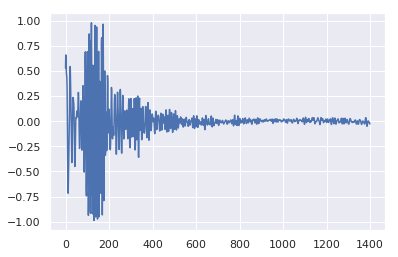

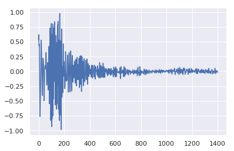

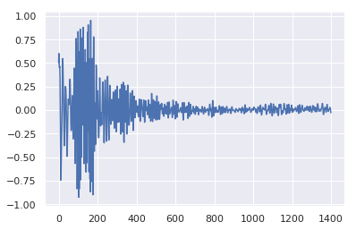

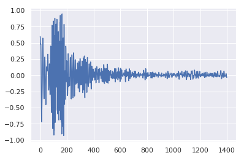

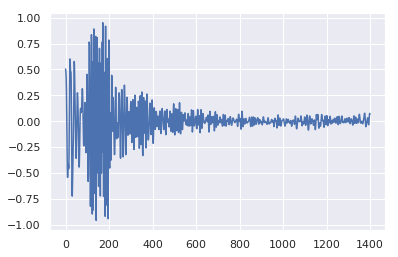

Looks great for the first second, lets apply to all data and gather as samples

```python
def get_samples(data_x, data_y, width = 1300, cutoff = 0.5):
    next_sample_idx = np.argmax(data_x > cutoff)
    beep = next_sample_idx
    prev_beep = next_sample_idx
    #out_x = np.empty((0, width))
    out_x = np.empty((0, width))
    out_y = []

    while next_sample_idx > 0 :
        sample = data_x[beep:beep+width]
        if (len(sample) < width):
            break

        out_x = np.concatenate((out_x, sample.reshape(1, width)), axis=0)
        out_y.append(data_y)

        next_sample_idx = np.argmax(data_x[beep+width:] > cutoff)
        prev_beep = beep;
        beep += width + next_sample_idx

    return (out_x, np.array(out_y))

#width = 1700*5 # how many concurrent samples to consider for chirp + data afterwards
width = 1400
data_beeps, _ = get_samples(data_x[0], data_y[0], width)
for sample in data_beeps[:10]:
    plt.plot(sample)
    plt.show()

display(Markdown('#### Looks great for the first second, lets apply to all data and gather as samples'))
```

```python
samples_x = np.empty((0, width))
samples_y = np.empty((0))
for x in range(0, len(data_x)):
    x_, y_ = get_samples(data_x[x], data_y[x], width)
    samples_x = np.concatenate((samples_x, x_))
    samples_y = np.concatenate((samples_y, y_))


print(samples_x.shape)
```

```
(24250, 1400)
```

```python
display(Markdown('#### Verify data lies within narrow bounds'))

std = np.std(samples_x[999:1000])
print(std)

print(samples_x[np.std(samples_x) > 0.199])
print(samples_x[np.std(samples_x) < 0.18])
```

Verify data lies within narrow bounds

```
0.20690016086198584
[]
[]
```

Spot check a few samples

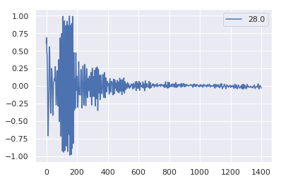

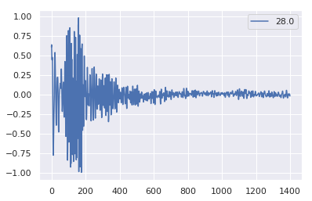

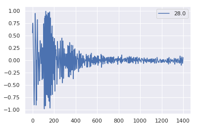

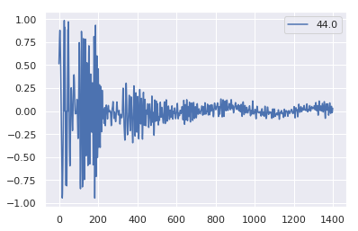

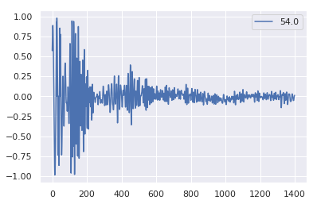

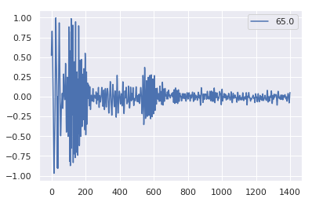

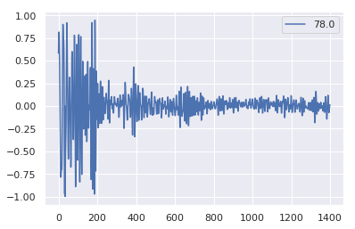

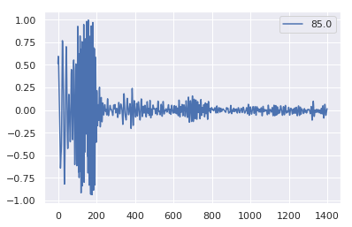

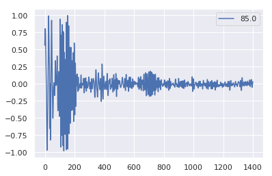

```python
display(Markdown('#### Spot check a few samples '))

for x in [0, 1, 3130, 6300, 9000, 12190, 15000, 18000, 20400]:
    plt.plot(samples_x[x], label = str(samples_y[x]))
    plt.legend(loc='upper right')
    plt.show()
```

Convert the distances to normalized values starting from index 0 and maintain a dict with the mappings for future use. Also one hot encode the distance indexes.

```python
from keras.utils import to_categorical

classes = np.unique(samples_y)
numClasses = len(classes)
print(classes)

idx_to_class = dict(enumerate(classes.flatten(), 0))
class_to_idx = {v: k for k, v in idx_to_class.items()}
print(class_to_idx)

data_y_idx = [class_to_idx[i] for i in samples_y ]

categorical_y = to_categorical(data_y_idx)
print(categorical_y[15000])
print(categorical_y[0].shape[0])
```

```
[28. 44. 54. 65. 78. 85. 94.]
{28.0: 0, 44.0: 1, 54.0: 2, 65.0: 3, 78.0: 4, 85.0: 5, 94.0: 6}
[0. 0. 0. 0. 1. 0. 0.]
7
```

```python
import math

display(Markdown('#### Finally, shuffle all the data and grab 10% for testing'))

from sklearn.utils import shuffle

samples_x, categorical_y = shuffle(samples_x, categorical_y, random_state=0)

cutoff_idx = int(math.floor(0.1*samples_x.shape[0]))
testing_x = samples_x[:cutoff_idx]
testing_y = categorical_y[:cutoff_idx]

samples_x = samples_x[cutoff_idx:]
categorical_y = categorical_y[cutoff_idx:]
```

Finally, shuffle all the data and grab 10% for testing

```python
from keras import regularizers

def create_model(sample_size, channel):
    input_signal = Input(shape=(sample_size, channel))
    x = Flatten()(input_signal)
    x = Dense(16, activation='tanh', kernel_regularizer=regularizers.l2(0.01))(x)
    x = BatchNormalization()(x)
    x = Dense(16, activation='tanh', kernel_regularizer=regularizers.l2(0.01))(x)
    x = BatchNormalization()(x)
    x = Dense(categorical_y[0].shape[0], activation='softmax')(x)
    return Model(inputs=input_signal, outputs=x)
```

```python
opt = optimizers.Nadam(lr=0.00001)

# we will flatten multiple channels so the input so channels = 1
model = create_model(width, 1)
model.compile(loss='categorical_crossentropy', optimizer=opt, metrics=['categorical_accuracy'])

model.summary()
```

```
_________________________________________________________________
Layer (type)                 Output Shape              Param #
=================================================================
input_6 (InputLayer)         (None, 1400, 1)           0
_________________________________________________________________
flatten_5 (Flatten)          (None, 1400)              0
_________________________________________________________________
dense_15 (Dense)             (None, 16)                22416
_________________________________________________________________
batch_normalization_8 (Batch (None, 16)                64
_________________________________________________________________
dense_16 (Dense)             (None, 16)                272
_________________________________________________________________
batch_normalization_9 (Batch (None, 16)                64
_________________________________________________________________
dense_17 (Dense)             (None, 7)                 119
=================================================================
Total params: 22,935
Trainable params: 22,871
Non-trainable params: 64
_________________________________________________________________
```

```python
def train(model, in_data_x, in_data_y, epochs, batch_size):
        return model.fit(in_data_x, in_data_y, validation_split=0.2, epochs=epochs, batch_size=batch_size, shuffle=True, verbose=2)
```

```python
history = train(model, samples_x.reshape(-1, width, 1), categorical_y, 150, 500)
```

```
Train on 17460 samples, validate on 4365 samples
 - 1s - loss: 2.8367 - categorical_accuracy: 0.1903 - val_loss: 2.3989 - val_categorical_accuracy: 0.2039
 - 0s - loss: 2.6964 - categorical_accuracy: 0.2194 - val_loss: 2.3718 - val_categorical_accuracy: 0.2284
 - 0s - loss: 2.5560 - categorical_accuracy: 0.2486 - val_loss: 2.3339 - val_categorical_accuracy: 0.2570
 - 0s - loss: 2.4199 - categorical_accuracy: 0.2763 - val_loss: 2.2841 - val_categorical_accuracy: 0.2779
 - 0s - loss: 2.2918 - categorical_accuracy: 0.3022 - val_loss: 2.2226 - val_categorical_accuracy: 0.3132
 - 0s - loss: 2.1721 - categorical_accuracy: 0.3332 - val_loss: 2.1513 - val_categorical_accuracy: 0.3567
 - 0s - loss: 2.0663 - categorical_accuracy: 0.3680 - val_loss: 2.0736 - val_categorical_accuracy: 0.3908
 - 0s - loss: 1.9728 - categorical_accuracy: 0.4066 - val_loss: 1.9936 - val_categorical_accuracy: 0.4318
 - 0s - loss: 1.8898 - categorical_accuracy: 0.4485 - val_loss: 1.9148 - val_categorical_accuracy: 0.4722
 - 0s - loss: 1.8176 - categorical_accuracy: 0.4885 - val_loss: 1.8397 - val_categorical_accuracy: 0.5134
 - 0s - loss: 1.7545 - categorical_accuracy: 0.5277 - val_loss: 1.7699 - val_categorical_accuracy: 0.5510
 - 0s - loss: 1.6969 - categorical_accuracy: 0.5655 - val_loss: 1.7059 - val_categorical_accuracy: 0.5874
 - 0s - loss: 1.6453 - categorical_accuracy: 0.5973 - val_loss: 1.6478 - val_categorical_accuracy: 0.6190
 - 0s - loss: 1.5976 - categorical_accuracy: 0.6286 - val_loss: 1.5953 - val_categorical_accuracy: 0.6488
 - 0s - loss: 1.5532 - categorical_accuracy: 0.6573 - val_loss: 1.5474 - val_categorical_accuracy: 0.6733
 - 0s - loss: 1.5129 - categorical_accuracy: 0.6820 - val_loss: 1.5039 - val_categorical_accuracy: 0.6987
 - 0s - loss: 1.4749 - categorical_accuracy: 0.7078 - val_loss: 1.4642 - val_categorical_accuracy: 0.7214
 - 0s - loss: 1.4405 - categorical_accuracy: 0.7317 - val_loss: 1.4272 - val_categorical_accuracy: 0.7432
 - 0s - loss: 1.4060 - categorical_accuracy: 0.7542 - val_loss: 1.3929 - val_categorical_accuracy: 0.7620
 - 0s - loss: 1.3756 - categorical_accuracy: 0.7737 - val_loss: 1.3612 - val_categorical_accuracy: 0.7782
 - 0s - loss: 1.3454 - categorical_accuracy: 0.7939 - val_loss: 1.3316 - val_categorical_accuracy: 0.7945
 - 0s - loss: 1.3173 - categorical_accuracy: 0.8107 - val_loss: 1.3037 - val_categorical_accuracy: 0.8085
 - 0s - loss: 1.2903 - categorical_accuracy: 0.8252 - val_loss: 1.2774 - val_categorical_accuracy: 0.8192
 - 0s - loss: 1.2654 - categorical_accuracy: 0.8370 - val_loss: 1.2526 - val_categorical_accuracy: 0.8289
 - 0s - loss: 1.2407 - categorical_accuracy: 0.8469 - val_loss: 1.2290 - val_categorical_accuracy: 0.8396
 - 0s - loss: 1.2177 - categorical_accuracy: 0.8565 - val_loss: 1.2067 - val_categorical_accuracy: 0.8474
 - 0s - loss: 1.1973 - categorical_accuracy: 0.8652 - val_loss: 1.1853 - val_categorical_accuracy: 0.8561
 - 0s - loss: 1.1761 - categorical_accuracy: 0.8725 - val_loss: 1.1652 - val_categorical_accuracy: 0.8653
 - 0s - loss: 1.1568 - categorical_accuracy: 0.8767 - val_loss: 1.1458 - val_categorical_accuracy: 0.8722
 - 0s - loss: 1.1377 - categorical_accuracy: 0.8836 - val_loss: 1.1274 - val_categorical_accuracy: 0.8784
 - 0s - loss: 1.1203 - categorical_accuracy: 0.8895 - val_loss: 1.1094 - val_categorical_accuracy: 0.8838
 - 0s - loss: 1.1024 - categorical_accuracy: 0.8946 - val_loss: 1.0926 - val_categorical_accuracy: 0.8887
 - 0s - loss: 1.0864 - categorical_accuracy: 0.8993 - val_loss: 1.0763 - val_categorical_accuracy: 0.8944
 - 0s - loss: 1.0707 - categorical_accuracy: 0.9041 - val_loss: 1.0610 - val_categorical_accuracy: 0.8999
 - 0s - loss: 1.0557 - categorical_accuracy: 0.9090 - val_loss: 1.0462 - val_categorical_accuracy: 0.9042
 - 0s - loss: 1.0409 - categorical_accuracy: 0.9123 - val_loss: 1.0319 - val_categorical_accuracy: 0.9077
 - 0s - loss: 1.0277 - categorical_accuracy: 0.9155 - val_loss: 1.0183 - val_categorical_accuracy: 0.9129
 - 0s - loss: 1.0141 - categorical_accuracy: 0.9203 - val_loss: 1.0052 - val_categorical_accuracy: 0.9155
 - 0s - loss: 1.0011 - categorical_accuracy: 0.9216 - val_loss: 0.9925 - val_categorical_accuracy: 0.9182
```

[output cut: 96 more lines]

```
 - 0s - loss: 0.4960 - categorical_accuracy: 0.9920 - val_loss: 0.4971 - val_categorical_accuracy: 0.9915
 - 0s - loss: 0.4934 - categorical_accuracy: 0.9920 - val_loss: 0.4943 - val_categorical_accuracy: 0.9918
 - 0s - loss: 0.4909 - categorical_accuracy: 0.9919 - val_loss: 0.4915 - val_categorical_accuracy: 0.9920
 - 0s - loss: 0.4882 - categorical_accuracy: 0.9920 - val_loss: 0.4888 - val_categorical_accuracy: 0.9920
 - 0s - loss: 0.4850 - categorical_accuracy: 0.9924 - val_loss: 0.4861 - val_categorical_accuracy: 0.9920
 - 0s - loss: 0.4828 - categorical_accuracy: 0.9922 - val_loss: 0.4834 - val_categorical_accuracy: 0.9924
 - 0s - loss: 0.4797 - categorical_accuracy: 0.9924 - val_loss: 0.4807 - val_categorical_accuracy: 0.9924
 - 0s - loss: 0.4771 - categorical_accuracy: 0.9925 - val_loss: 0.4781 - val_categorical_accuracy: 0.9924
 - 0s - loss: 0.4744 - categorical_accuracy: 0.9927 - val_loss: 0.4754 - val_categorical_accuracy: 0.9931
 - 0s - loss: 0.4714 - categorical_accuracy: 0.9931 - val_loss: 0.4728 - val_categorical_accuracy: 0.9931
 - 0s - loss: 0.4688 - categorical_accuracy: 0.9936 - val_loss: 0.4703 - val_categorical_accuracy: 0.9931
 - 0s - loss: 0.4663 - categorical_accuracy: 0.9935 - val_loss: 0.4677 - val_categorical_accuracy: 0.9931
 - 0s - loss: 0.4637 - categorical_accuracy: 0.9938 - val_loss: 0.4650 - val_categorical_accuracy: 0.9931
 - 0s - loss: 0.4613 - categorical_accuracy: 0.9937 - val_loss: 0.4625 - val_categorical_accuracy: 0.9931
 - 0s - loss: 0.4586 - categorical_accuracy: 0.9935 - val_loss: 0.4599 - val_categorical_accuracy: 0.9931
```

```python
def plot(history):
    # Plot training & validation loss values
    plt.plot(history.history['loss'])
    plt.plot(history.history['val_loss'])
    plt.title('Model loss')
    plt.ylabel('Loss')
    plt.xlabel('Epoch')
    plt.legend(['Train', 'Validation'], loc='upper left')
    plt.show()

    # Plot training & validation accuracy values
    plt.plot(history.history['categorical_accuracy'])
    plt.plot(history.history['val_categorical_accuracy'])
    plt.title('Model accuracy')
    plt.ylabel('Accuracy')
    plt.xlabel('Epoch')
    plt.legend(['Train', 'Validation'], loc='upper left')
    plt.show()
```

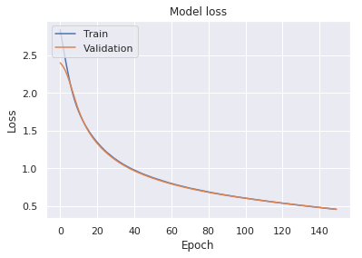

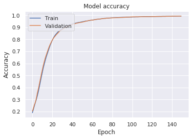

```python
plot(history)
```

```python
display(Markdown('#### Everything looks good. Lets see what sort of accuracy we get on the testing set '))

loss, acc = model.evaluate(testing_x.reshape(-1, width, 1), testing_y)
print('\nTesting loss: {}, acc: {}\n'.format(loss, acc))
```

Everything looks good. Lets see what sort of accuracy we get on the testing set

```
Testing loss: 0.46989463798778575, acc: 0.9917525773195877
```

### Further steps and investigations

From the analysis above, its clear that the data is not of very high quality and the S/N ratio is quite low. This is why its hard for us to visually distinguish some of the samples. Still we were able to achieve > 99% accuracy from our testing set.

Some next steps are outlined below.

- Gather more data. This will give us a better gauge of the effectiveness of the model.
- Look at the failed cases in more detail and see if we can spot the issues there.
- Remove the original chirp from the data so we are feeding the network less noise.
- Experiment with some blurring/averaging techniques to see if that can bring out the signal better.
- Use a different mic. This was captured with a ps3 eye toy 4 microphone array with low fidelity.
- Try different waveforms for the chirp to see if perhaps different frequencies yield better results.
- I am also curious about how general this trained model is to variations in ambient noise.